# Associations Between Two Quantitative Variables (Section 2.5 - 2.6 Continued)

Day 8

Claire Kelling

Carleton College  
STAT 120 - Fall 2026

## Question of the Day

How are you feeling about the quiz on Friday? Do you have a study plan?

## Today’s Topics

**Logistics:**

- Questions on the Short Report?
- **Quiz 1:** Friday Oct 2
  - You can bring a handwritten one-sided sheet of paper (8.5 x 11)
  - You will not be asked to write R code, but you should be able to interpret R output (for example, the output from *summary()* or plots)
- Finding intercept and slope: use **technology**
- Homework 4 is posted, due on the same day as the short report (have everything you need for this after today!)
- Reminder of AI use citation at the top of homework files!
- Log out of Maize sessions when you are done! Prevents issues down the road.
- Bring your friend to comps on Thursday October 8 from 1:15-3pm???

**Topics covered today:**

- Continuing associations Between Two Quantitative Variables
  - Residual Plots
  - R-squared
  - Outliers

# Residual Plots

## Recall: Regression model residuals

The **residuals** for a model are

$$y - \hat{y}$$

Residuals are used to:

- Check a model: is the association really linear?
- If the model is linear, measure how much variation in the response is explained by the model.

The residual plot “detrends” the scatterplot

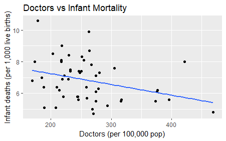

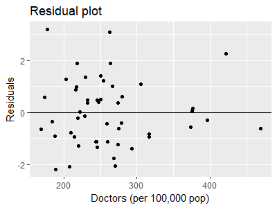

## Residual Plots

**Definition**

**Residual Plot**: a scatterplot with

- x-axis: explanatory variable
- y-axis: residuals, $y - \hat{y}$, from the model

**What to look for:**

- **no pattern** (a null plot): indicates good model fit
- **curvature**: then your model is not good!
- It can also help to reveal outliers

## Residuals: Forbes Experiment

**Question**

James D. Forbes 1857 experiment: Can atmospheric pressure be determined from the boiling point of water?

- $y$ = pressure
- $x$ = boiling point of water (temp)

Is the relationship linear?

Scatterplot:

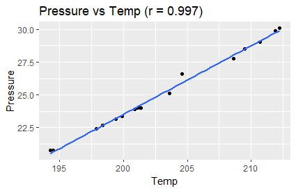

## Residuals: Forbes Experiment

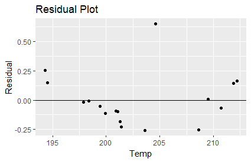

Is the relationship between pressure and temp linear?

- **No**. There is a curved relationship so a line should not be used to describe the relationship.
- A line would
  - overestimate pressure for “middle” temps
  - underestimate pressure for low/high temps
- Turns out that temp and log(pressure) have a linear relationship!

## Residual Plots in R

1. Fit linear model (using lm() function)

```r
#linear model code
nba_lm <- lm(blk ~ wingspan_inches, data = nba)
```

## Residual Plots in R

1. Fit linear model
2. Get residuals

*broom* package: **augment()** function adds residuals to a lm’s x/y variables

```r
nba_aug <- augment(nba_lm)
nba_aug
```

```
# A tibble: 387 × 8
     blk wingspan_inches .fitted .resid    .hat .sigma   .cooksd
   <dbl>           <dbl>   <dbl>  <dbl>   <dbl>  <dbl>     <dbl>
 1   0.2            80.5   0.725 -0.525 0.00335  0.633 0.00116
 2   0.5            83.8   1.19  -0.690 0.00281  0.633 0.00168
 3   0.7            79.5   0.582  0.118 0.00424  0.634 0.0000750
 4   0.7            82     0.940 -0.240 0.00265  0.634 0.000191
 5   0.5            81.8   0.904 -0.404 0.00271  0.633 0.000554
 6   3.8            87.8   1.76   2.04  0.00715  0.625 0.0376
 7   0.3            78.2   0.402 -0.102 0.00585  0.634 0.0000776
 8   1.5            84.8   1.33   0.167 0.00338  0.634 0.000118
 9   0.4            82     0.940 -0.540 0.00265  0.633 0.000967
10   1.4            78     0.367  1.03  0.00624  0.632 0.00841
# ℹ 377 more rows
# ℹ 1 more variable: .std.resid <dbl>
```

## Residuals Plot with R Code

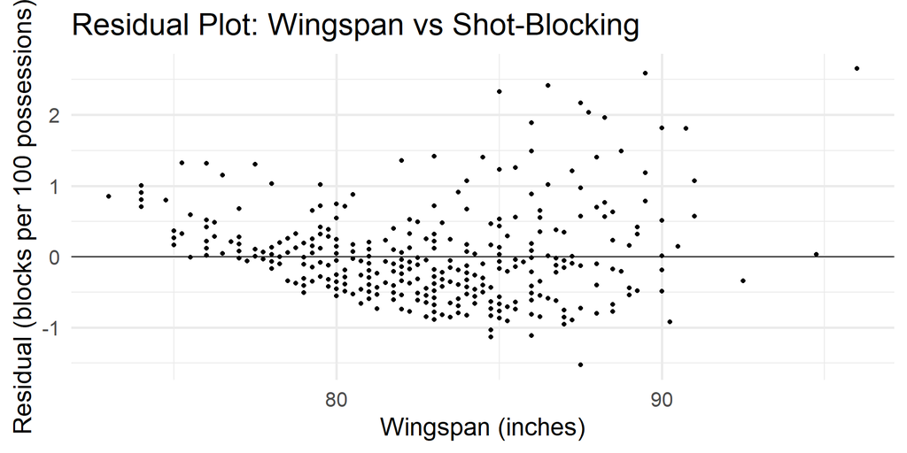

So? Is the relationship linear?

```r
#Residual Plot
ggplot(nba_aug, aes(x = wingspan_inches, y = .resid)) +
  geom_point() +
  geom_hline(yintercept = 0) +
  labs(x = "Wingspan (inches)",
       y= "Residual (blocks per 100 possessions)",
       title= "Residual Plot: Wingspan vs Shot-Blocking")
```

# R-squared

## R-squared

**Definition**

**R-squared** measures the proportion (or percentage) of **variability** observed in the response $y$ which can be explained by the explanatory variable $x$.

$$R^2 = \text{explained variation} = 1 - \text{unexplained variation} = 1 - \frac{sd(resid)^2}{sd(y)^2}$$

- Residuals give us information about what we *weren’t* about to explain
- $sd(y)^2$: variation in $y$ (standard deviation of $y$, squared)
- $sd(resid)^2$: variation from residuals, square of the standard deviation of the residuals
- R-squared is the correlation coefficient squared in a **simple** linear regression model (one explanatory variable)

## R-squared Interpretation

**Interpretation**

**Regression of blocks per 100 possessions on wingspan for NBA players**:

$$R^2 = 0.4354$$

- Wingspan explains about 43.5% of the observed variation in blocks per 100 possessions.
- What factors (variables) besides wingspan might explain the other roughly 56.5% of variation in shot-blocking?

## R-squared in R

**R code**

```r
#linear model code
summary(nba_lm)
```

```
Call:
lm(formula = blk ~ wingspan_inches, data = nba)

Residuals:
     Min       1Q   Median       3Q      Max
-1.52737 -0.42236 -0.08153  0.25799  2.65517

Coefficients:
                  Estimate Std. Error t value Pr(>|t|)
(Intercept)     -10.805310   0.687383  -15.72   <2e-16 ***
wingspan_inches   0.143231   0.008312   17.23   <2e-16 ***
---
Signif. codes:  0 '***' 0.001 '**' 0.01 '*' 0.05 '.' 0.1 ' ' 1

Residual standard error: 0.633 on 385 degrees of freedom
Multiple R-squared:  0.4354,    Adjusted R-squared:  0.4339
F-statistic: 296.9 on 1 and 385 DF,  p-value: < 2.2e-16
```

(**Not** adjusted R-squared!)

## Digging Deeper in R-Squared

Can also calculate $R^2$ using variation in R.

**Using Variation**

```r
#variation in "y"
sd(nba$blk)^2
```

```
[1] 0.707828
```

```r
#residual variation
sd(nba_aug$.resid)^2
```

```
[1] 0.3996392
```

```r
#calculate R-squared:
1 - sd(nba_aug$.resid)^2/sd(nba$blk)^2
```

```
[1] 0.4354006
```

# Adding a Categorical Variable

## Adding a Categorical Variable

We should include confounding variables when possible/appropriate.

Two approaches (of many):

- Augment scatterplot with colors for each category
- Split (subset) data by categories, fit regressions for each group.

## Example: Position as a Confounder?

**Continuing our wingspan analysis:**

- Wingspan and blocks per 100 possessions
- They are positively correlated!
- **But** — bigs (centers/forwards) tend to have both longer wingspans *and* play closer to the rim (more blocks). Is *position* driving this relationship?

```r
cor(nba$wingspan_inches, nba$blk)
```

```
[1] 0.6598489
```

## Example: Position as a Confounder?

Plot the bivariate data

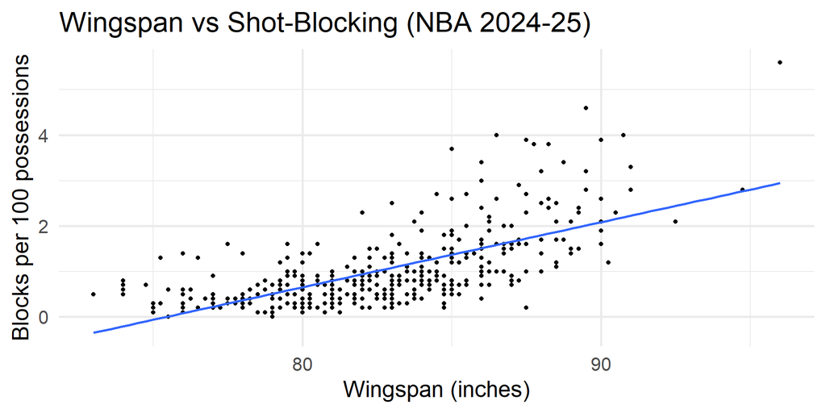

```r
ggplot(nba, aes(x = wingspan_inches, y = blk)) +
  geom_point() +
  geom_smooth(method = "lm", se = FALSE)+
  labs(x = "Wingspan (inches)",
       y= "Blocks per 100 possessions",
       title= "Wingspan vs Shot-Blocking (NBA 2024-25)")+
  theme_minimal(base_size = 20)
```

## Add Position (Confounder)

Let’s add a regression line for each group (Guard vs Big)

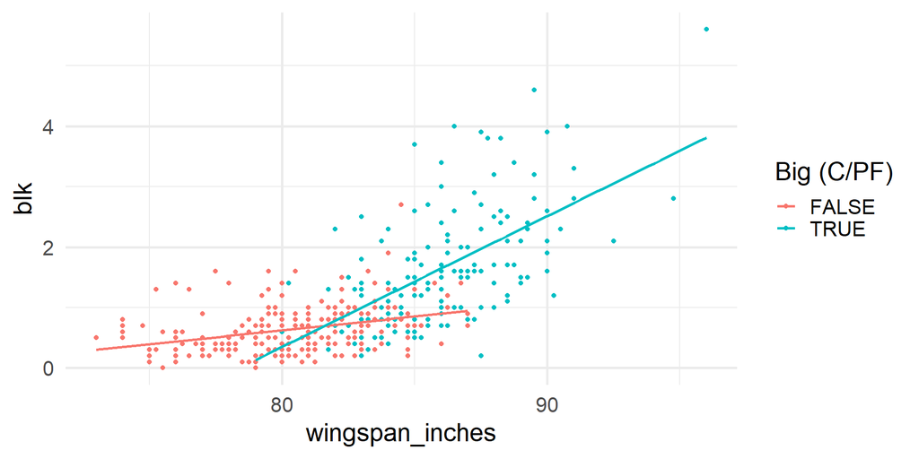

```r
#add info on position group
ggplot(nba, aes(x = wingspan_inches, y = blk,
        col = position %in% c("C", "PF"))) +
  geom_point() +
  geom_smooth(method = "lm", se = FALSE) +
  labs(color = "Big (C/PF)")+
  theme_minimal(base_size = 20)
```